# Problem Set 02

Alwin Eldhose Babu

10/21/2021

# 1 COVID-19 Data

## 1.1 Load a single month of African data

### 1.1.1 Loading the list of African countries countries-africa.csv and counting the number of African countries

```r
africa_data = read.delim("covid/countries-africa.csv.bz2")
nrow(africa_data)
```

```
## [1] 58
```

The function read.delim() is used for reading a datafile here. Thus, we see that the dataset ‘countries-africa.csv.bz2’ contains **58** countries

### 1.1.2 Collect all the names of covid data files covid-global into a character vector. How many files are there?

```r
gbl_filenames <- list.files("covid/", pattern = "covid.global*")
length(gbl_filenames)
```

```
## [1] 21
```

The filenames of data files with covid-global in their names were collected and stored into the character vector ‘gbl_filenames’. The function list.files is used to produce a character vector by giving the path to the files and the pattern of the filenames, i.e. it begins with ‘covid.global’. There are **21** files that contain covid global data.

### 1.1.3 Load the COVID data file for October 2021. Ensure you know the variables there

```r
oct21_data <- read.delim("covid/covid-global_10-01-2021.csv.bz2")
names(oct21_data)
```

```
##  [1] "FIPS"                "Admin2"              "Province_State"
##  [4] "Country_Region"      "Last_Update"         "Lat"
##  [7] "Long_"               "Confirmed"           "Deaths"
## [10] "Recovered"           "Active"              "Combined_Key"
## [13] "Incident_Rate"       "Case_Fatality_Ratio"
```

### 1.1.4 How many African countries in the African Country list do you find in the covid data?

```r
length(which(africa_data$country %in% oct21_data$Country_Region))
```

```
## [1] 49
```

The function which() is used to obtain the matching indices of countries which are there in the african countries list and are common to the global countries list. The number of common countries is observed to be 49 countries

### 1.1.5 Which African countries are not matched in the COVID data? Again, do not adjust the names for now.

```r
africa_data$country[which(!(africa_data$country %in% oct21_data$Country_Region))]
```

```
## [1] "Democratic Republic of the Congo"
## [2] "Ivory Coast"
## [3] "Republic of the Congo"
## [4] "RÃ©union (France)"
## [5] "Western Sahara"
## [6] "Cape Verde"
## [7] "Mayotte (France)"
## [8] "SÃ£o TomÃ© and PrÃncipe"
## [9] "Saint Helena, Ascension and Tristan da Cunha (UK)"
```

We obtain the indices of countries which are not there in the global list of countries using the which() function and using a ! operator. The indices are then passed on to the african datalist africa_data to print the list of countries that did not match.

### 1.1.7 Next, find how are the names of these three countries (Two Congos and Ivory Coast) written in the covid data.

Democratic Republic of the Congo is written as Congo (Kinshasa), Republic of the Congo is written as Congo (Brazzaville), Ivory Coast is written as Cote d’Ivoire.

### 1.1.8 Amend the list of African countries in a way that you can extract all the necessary African countries (you may leave out the islands/territories) from COVID data. Demonstrate that it works.

```r
updated_africa_data <- africa_data
updated_africa_data$country[updated_africa_data$country=="Democratic Republic of the Congo"] <- "Congo (Kinshasa)"
updated_africa_data$country[updated_africa_data$country=="Republic of the Congo"] <- "Congo (Brazzaville)"
updated_africa_data$country[updated_africa_data$country=="Ivory Coast"] <- "Cote d'Ivoire"
updated_africa_data$country[which(!(updated_africa_data$country %in% oct21_data$Country_Region))]
```

```
## [1] "RÃ©union (France)"
## [2] "Western Sahara"
## [3] "Cape Verde"
## [4] "Mayotte (France)"
## [5] "SÃ£o TomÃ© and PrÃncipe"
## [6] "Saint Helena, Ascension and Tristan da Cunha (UK)"
```

We created a new variable called updated_africa_data to copy the africa_data content with the updated country lists.

## 1.2 Load and merge all datasets

### 1.2.1 The file name is written as “covid-global_--.csv.bz2”, and date always “01” in these files. Extract the date part from the first file name as Date object.

```r
Date <- gsub(".*[_]|[.].*", "", gbl_filenames[1])
Date <- as.Date(Date, "%m-%d-%Y")
Date
```

```
## [1] "2021-01-01"
```

The function **gsub()** is used to extract the content of the filename with the Date, which is in a character vector. **Date** is then converted to Date format using the function **as.Date()**

### 1.2.2 Now it is time to merge all the data files into one.

```r
merged_df <- NULL #Null dataset is created

for (i in 1:length(gbl_filenames))
{
    local <- read.delim(paste("covid/", gbl_filenames[i], sep = ""))

    if('Country.Region' %in% colnames(local))
    {
      colnames(local)[which(names(local) == "Country.Region")] <- "Country_Region"
    }

      local <- local %>% select('Country_Region', 'Deaths')
      local <-
        filter(local,local$Country_Region %in% updated_africa_data$country)

    Date_local <- gsub(".*[_]|[.].*", "", gbl_filenames[i])
    Date_local <- as.Date(Date_local, "%m-%d-%Y")
    local <- local %>% mutate('Year' = lubridate::year(Date_local), Month = lubridate::month(Date_local))

    merged_df <- rbind(merged_df,local)
}

head(merged_df)
```

```
##   Country_Region Deaths Year Month
## 1        Algeria   2762 2021     1
## 2         Angola    405 2021     1
## 3          Benin     44 2021     1
## 4       Botswana     42 2021     1
## 5   Burkina Faso     85 2021     1
## 6        Burundi      2 2021     1
```

```r
dim(merged_df)
```

```
## [1] 986   4
```

We load the file into a dataframe **merged_df** which is first created as NULL and then loaded with the contents of each file. We first extract African countries only, and preserve only the number of deaths and the country names. The variable containing the country names is not consistent and differs across different datasets which is made consistent. We created a merged dataset containing the year and month from the file name and add it to the extracted data. We also added the year and month as variables to the merged dataset. The dim() function is used to obtain the number of rows and columns of the merged dataset.

## 1.3 Display Time Series

### 1.3.1 Extract the population size from the dataset of African countries. Ensure the result is a valid number, you need to do some math with it next

```r
  african_population <- updated_africa_data %>% select(country,population)
  african_population$population <- gsub(",","",african_population$population)

  african_population$population <- as.numeric(african_population$population)
  head(african_population)
```

```
##            country population
## 1          Nigeria  206139589
## 2         Ethiopia  109224414
## 3 Congo (Kinshasa)  102561403
## 4            Egypt  101334404
## 5     South Africa   59956820
## 6         Tanzania   59734218
```

The population of countries in Africa were extracted by selecting them using select() function. The population contained commas in the number which was removed using gsub() function. The population was then converted to a numeric variable using the as.numeric() function.

### 1.3.2 For each country, compute the death rate: number of deaths per 1M population.

```r
  updated_merged_df <- merge(merged_df, african_population, by.x="Country_Region", by.y="country",all.x=TRUE)
 updated_merged_df2 <- updated_merged_df %>%
   mutate('Death_Rate' = round(Deaths*1000000/population,2))

head(updated_merged_df2)
```

```
##   Country_Region Deaths Year Month population Death_Rate
## 1        Algeria   2762 2021     1   43000420      64.23
## 2        Algeria   5302 2021     9   43000420     123.30
## 3        Algeria   3261 2021     5   43000420      75.84
## 4        Algeria   1518 2020     9   43000420      35.30
## 5        Algeria    453 2020     5   43000420      10.53
## 6        Algeria   4291 2021     8   43000420      99.79
```

The dataset is merged with the african population. We created the column “Death_Rate” by calculating deaths/population for each million of population.

### 1.3.3 Which 10 countries have the largest death rate?

```r
top10_countries_oct<- updated_merged_df2 %>% group_by(Country_Region) %>% filter(Year == 2021 & Month == 10) %>% summarize(Avg_Death_rate=round(Death_Rate/n(),2)) %>% arrange(desc(Avg_Death_rate)) %>% head(10)
top10_countries_oct
```

```
## # A tibble: 10 x 2
##    Country_Region Avg_Death_rate
##    <chr>                   <dbl>
##  1 Tunisia                 2267.
##  2 Namibia                 1541.
##  3 South Africa            1463.
##  4 Seychelles              1232.
##  5 Botswana                1169.
##  6 Eswatini                1093.
##  7 Libya                    880.
##  8 Morocco                  386.
##  9 Zimbabwe                 354.
## 10 Lesotho                  315.
```

The data was arranged in descending order by death rate to get top 10 countries with the largest death rate.

### 1.3.4 Make a plot where you show how the death rate has grown in these 10 countries over time. Ensure the plot is appropriately labelled and uses appropriate plot type, colors, and other visual details.

```r
updated_merged_df_plot <- updated_merged_df2 %>% filter(Country_Region %in% top10_countries_oct$Country_Region) %>% arrange(Country_Region)
head(updated_merged_df_plot)
```

```
##   Country_Region Deaths Year Month population Death_Rate
## 1       Botswana     42 2021     1    2024904      20.74
## 2       Botswana    712 2021     5    2024904     351.62
## 3       Botswana      1 2020     6    2024904       0.49
## 4       Botswana   1158 2021     7    2024904     571.88
## 5       Botswana      6 2020     9    2024904       2.96
## 6       Botswana   1569 2021     8    2024904     774.85
```

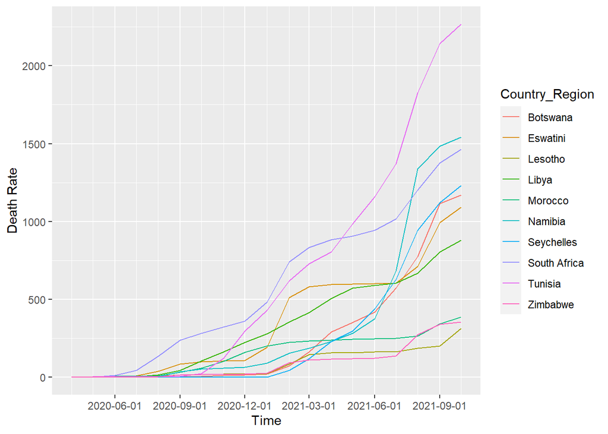

```r
ggplot(updated_merged_df_plot, aes(x=as.Date(paste0(Year,"-",Month,"-","01","%Y-%m-%d")),y=Death_Rate,col = Country_Region)) + geom_line() +scale_x_date(date_breaks = "3 month",minor_breaks = "1 month") + xlab("Time") + ylab("Death Rate")
```

Firstly, the data for the top 10 countries was obtained by filtering it with the list of 10 countries. Then, a graph was plotted after creating a date variable to make the graph consistent. A line graph was used to show death rate of all the regions. The argument scale_x_date was used to reduced the numnber of the labels of the x axis to 3 months for better representation of graph. Then, xlab and ylab were used to properly label the graph.

### 1.3.5 How much has the death rate grown from one month to another in these 10 countries? Compute the number of new monthly deaths (per 1M population) and display on a similar plot.

```r
#updated_merged_df_plot <- updated_merged_df2 %>% filter(Country_Region %in% top10_countries_oct$Country_Region) %>% arrange(desc(Month))

updated_merged_df_plot_monthly <- updated_merged_df_plot %>% mutate(Date = as.Date(paste0(Year,"-",Month,"-","01","%Y-%m-%d"))) %>%
  group_by(Country_Region) %>%
  mutate(Monthly_Deaths = Deaths - lag(Deaths, default = 0, order_by = Date)) %>% arrange(Country_Region, Year, Month) %>% mutate('Monthly_Death_Rate' = round(Monthly_Deaths*1000000/population,2))
head(updated_merged_df_plot_monthly)
```

```
## # A tibble: 6 x 9
## # Groups:   Country_Region [1]
##   Country_Region Deaths  Year Month population Death_Rate Date
##   <chr>           <int> <dbl> <dbl>      <dbl>      <dbl> <date>
## 1 Botswana            1  2020     4    2024904       0.49 2020-04-01
## 2 Botswana            1  2020     5    2024904       0.49 2020-05-01
## 3 Botswana            1  2020     6    2024904       0.49 2020-06-01
## 4 Botswana            1  2020     7    2024904       0.49 2020-07-01
## 5 Botswana            2  2020     8    2024904       0.99 2020-08-01
## 6 Botswana            6  2020     9    2024904       2.96 2020-09-01
## # ... with 2 more variables: Monthly_Deaths <dbl>, Monthly_Death_Rate <dbl>
```

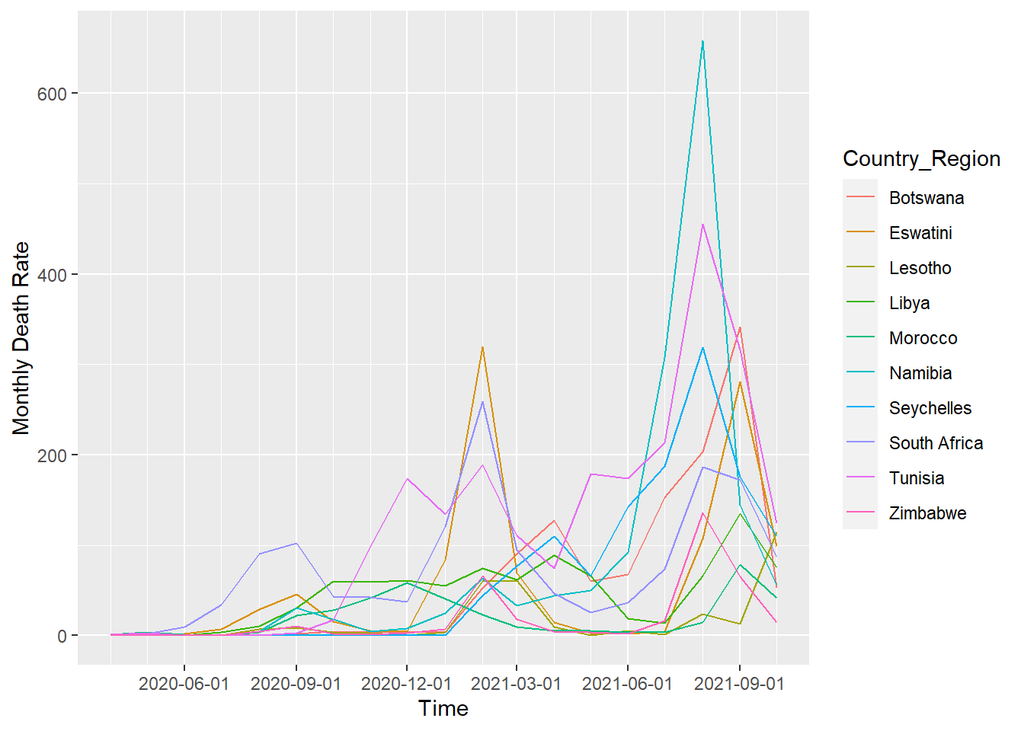

```r
ggplot(updated_merged_df_plot_monthly, aes(x=Date,y=Monthly_Death_Rate,col = Country_Region)) + geom_line() +scale_x_date(date_breaks = "3 month", minor_breaks = "1 month") + xlab("Time") + ylab("Monthly Death Rate")
```

A new column “Date” was created for easy use of lag function. Then, another column was created another “Monthly_Deaths” where lag function was used to create monthly death which was ordered by “Country”, “Year” and “Month”. Then, another new column was created which was to calculate the monthly death rate. Then, another graph was plotted with X axis and Monthly death rate on Y axis. Then scale_x_date was used to remove the number of labels on x axis to 3 months for better representation of graph. Then, xlab and ylab were used to label the graph.

### 1.3.6 Which country out of these 10 experienced the highest peak in the new monthly deaths? When was that? How many COVID “waves” can you see on the plot?

```r
updated_merged_df_plot_monthly <- updated_merged_df_plot_monthly %>% arrange(desc(Monthly_Death_Rate))
head(updated_merged_df_plot_monthly, 3)
```

```
## # A tibble: 3 x 9
## # Groups:   Country_Region [3]
##   Country_Region Deaths  Year Month population Death_Rate Date
##   <chr>           <int> <dbl> <dbl>      <dbl>      <dbl> <date>
## 1 Namibia          3057  2021     8    2280700      1340. 2021-08-01
## 2 Tunisia         20067  2021     8   10982754      1827. 2021-08-01
## 3 Botswana         2261  2021     9    2024904      1117. 2021-09-01
## # ... with 2 more variables: Monthly_Deaths <dbl>, Monthly_Death_Rate <dbl>
```

Namibia is the country that experienced the highest peak in the new monthly deaths, which occured in August 2021. On the plot, we can see 2 Covid “Waves” in the plot, the first one occured around February 2021, and the second one occured around August 2021.

## 1.4 Think about this

### 1.4.1 Where would the US be on the top-10 list of African countries?

USA has total deaths of about 700,000 and a population of about 329.5 million, which translates to about an average death rate of 2124.43 deaths per million. This, in comparison to the top 10 african countries, comes in the second place after Tunisia, which has a death rate of 2267.28 per million. Therefore USA would rank second on the top-10 list of African countries. Reference: 1. https://www.google.com/search?q=us+population&rlz=1C5CHFA_enUS974US974&oq=us+population&gs_lcp=Cgdnd3Mtd2l6EAMYADIHCAAQsQMQQzIICAAQgAQQsQMyBQgAEIAEMgcIABCx…&sclient=gws-wiz 2. https://www.google.com/search?q=us+covid&rlz=1C5CHFA_enUS974US974&ei=cMxzYcnDG9ra0PEPw-2DmAQ&ved=0ahUKEwjJu_uRk-DzAhVaLTQIHcP2AEMQ4dUDCA4&uact=5&oq=us+covid&gs_lcp=Cgdnd3Mtd2l6EAMyBwgAELEDEEMyCAgAEIAEELEDMgcIABCxAxBDMgcIABCx…-XAli0hpgCYMmImAJoCHACeACAAa0BiAGTG5IBBDQuMjeYAQCgAQHIAQjAAQE&sclient=gws-wiz

### 1.4.2 What do you think about reliability of these data?

Reference : https://www.google.com/search?q=tunisia+covid+cases+deaths&rlz=1C5CHFA_enUS974US974&ei=nN5zYbb6N5fB0PEP5L2W8A4&oq=tunisia+covid+cases+deaths&gs_lcp=Cgdnd3Mtd2l6EAMYADIICCEQFhAdEB46BwgAELEDEEM6CAgAEIAEELEDOgUI…&sclient=gws-wiz

### 1.4.3 What recommendations would you give for the data collection team regarding to how collect/store data?

- Through the analysis, some inconsistencies were observed in the data, For example, the African countries like Democratic Republic of Congo and Republic of Congo, as well as Ivory Coast had been given these names instead of their U.N. recognized names from the original list. Standard names should have been used in the nomenclature of countries and regions.
- The names of variables could be named more appropriately. For eg., the ‘Deaths’ column referred to the total number of deaths as of date. This could have been better identified as ‘Cumulative_Deaths’. Additionally, the coding of column names also were inconsistent. For example, some columns had ‘Country_Region’, while some had ‘Country.Region’, which is confusing.
- Additionally, some observations did not have all the characters in the dataset readily available. For example, some characters were found to be Null or NA. This could have been avoided.